# Aula Text Mining

# Análise de texto no R

A quantidade de informações geradas atualmente são incríveis e consequentemente a forma como eles estão estruturados pode variar muito, entre elas, o casos dos textos.

Análise de texto não é algo relativamente novo, podemos notar isso em *papers* e livros sobre análise de discurso ou conteúdo. Ocorre que o poder computacional foi capaz de trazer análises ainda mais escaláveis do que se fazia antes e com uma força quantitativa muito mais robusta.

No **R** existem muitos pacotes para lidar com textos, que vão desde contar frequência de palavras até rodar modelos estatísticos. Vamos tentar percorrar estes tópicos utilizando como bases os discursos da Dilma e do Temer.

Estes discursos foram obtidos utilizando webscraping e seu código está disponível [aqui](https://github.com/ngiachetta/OficinaCIS-USP/blob/master/WebScraping.Rmd). Não recomedo baixá-los novamente, vai demorar uma eternidade!

## Revisando estrutura de dados: strings

Ao longo das aulas vimos como podemos guardar variáveis tipo texto no R. Estes objetos devem sempre estar entre aspas, sejam as aspas simples `''` ou duplas `""`.

```r
c("Oi", "Tudo", "bem")
```

Estes tipos de objetos podem ser manipulados assim como tantos outros objetos, porém não podemos, por exemplo, fazer a média de `c("Oi", "Tchau")`. Uma das principais função para manipulação de texto no **R** é o **stringr** criado por Hadley Wickham. Vamos ver como ele funciona!

## **stringr**

A maior parte das funções do **stringr** tem como prefixo `str_`, como por exemplo, `str_replace()`, `str_detect()` ou `str_extract()` e para habilitar ela para uso fazemos,

```r
# install.packages("stringr")
library(stringr)
```

Vamos usar o seguinte vetor como exemplo:

```r
textos <- c("Programacao em R", "Ciências Sociais", "Sociologia", "Programar é legal", "HaDlEy WiCkHaM", "R")
```

### `str_lenght()`

O `str_lenght()` serve para verificarmos o número de caracteres das palavras. Note que ele é diferente da função `length()` que apenas conta a quantidade de elementos no vetor.

```r
str_length(textos)

length(textos)
```

### `str_c()`

O `str_c()` nos ajuda a concatenar as strings em uma única. Vamos ver um exemplo concatenando os elementos das posições um e dois do nosso vetor “textos”.

```r
str_c(textos[1], textos[2], sep = " para ")
```

Basicamente, colamos “Programacao em R” e “Ciências Sociais” separado por " para “. Simples, não?

### `str_to_lower()`, `str_to_title()`, `str_to_upper()`

Estas funções são bem intuitivas, olha só:

```r
str_to_lower(textos)
```

```r
str_to_title(textos)
```

```r
str_to_upper(textos)
```

### `str_replace()` e `str_replace_all()`

A função `str_replace()` e `str_replace_all()` localizam um padrão e o substituem por algo de seu interesse, por exemplo, queremos substituir todas as letras r dos elementos do nosso vetor por Python.

```r
str_replace(textos, "R", "Python")
```

[output not shown]

Ops, parece que o r em caixa baixa é diferente do R em caixa alta! Isso significa que estas funções são case-sensitive, ou seja, precisamos especificar que queremos transformar tanto “r” e “R” em Python.

```r
mud_R <- str_replace(textos, "R", "Python")
mud_r <- str_replace(mud_R, "r", "Python")
mud_r
```

[output not shown]

Parece que ainda não deu certo! O elemento “PPythonogramar é legal” ainda tem “r” que não foram substituídos. Para solucionar esse problema nós utilizamos `str_replace_all()` que vai substituir todos os padrões do texto.

```r
mud_R <- str_replace_all(textos, "R", "Python")
mud_r <- str_replace_all(mud_R, "r", "Python")
mud_r
```

### `str_detect()`

O `str_detect()` irá detectar se existe um padrão específico nos seus textos, como por exemplo, vamos detectar em quais elementos aparecem a palavra programar.

```r
str_detect(textos, "Programar")
```

### `str_extract()`

O `str_extract()` extraí um padrão dos elementos do texto.

```r
str_extract(textos, "Programar")
```

## Expressões Regulares (Regex)

Existem formas de sinalizarmos alguns padrões nos textos, como por exemplo, falar que queremos o r em caixa baixa ou o R em caixa alta. Estas formas de sinalizar padrões são chamadas de expressões regulares. No wikipedia a definição de regex é a seguinte,

> “uma forma concisa e flexível de identificar cadeias de caracteres de interesse, como caracteres particulares, palavras ou padrões de caracteres”

Dê uma pausa e leia o material do Curso R sobre expressões regulares: http://material.curso-r.com/stringr/#express%C3%B5es-regulares

Agora que temos uma noção melhor sobre como manipular textos, vamos analisar os discursos da Dilma e Temer!

## Análise dos discurso da Dilma e Temer

Vamos habilitar os pacotes que utilizaremos e abrir os dados com os discursos.

```r
library(tidyverse)
library(lubridate)
library(quanteda)
library(wordcloud2)
library(stringr)
library(tidytext)
library(SnowballC)
```

```r
discursos <- read_csv("data/discursos.csv")
```

O banco de dados tem apenas 5 variáveis, com informações sobre a data, o título do discurso, o link para os discursos, quem os proferiu e o seu cunteúdo. Vamos começar fazendo algumas transoformações básicas.

```r
glimpse(discursos)
```

```
Observations: 1,140
Variables: 5
$ date           <chr> "12/05/2016 14h22", "10/05/2016 20h47", "09/05/2016 20h45", "09/05/2016 15h21", "07/05/2016 17h03", "06/05/20...
$ title          <chr> "Declaração à imprensa da Presidenta da República, Dilma Rousseff - Brasília/DF", "Discurso da Presidenta da ...
$ discourse      <chr> "Bom dia. Bom dia senhores e senhoras jornalistas, bom dia - aqui tem parlamentares, ministros, bom dia a tod...
$ link_discourse <chr> "http://www2.planalto.gov.br/acompanhe-o-planalto/discursos/discursos-da-presidenta/declaracao-a-imprensa-da-...
$ who            <chr> "Dilma", "Dilma", "Dilma", "Dilma", "Dilma", "Dilma", "Dilma", "Dilma", "Dilma", "Dilma", "Dilma", "Dilma", "...
```

A primeira transformação que faremos vai ser transformar a variável `date` em um objeto interpretado como data e não string, em seguida transformaremos todas as outras variáveis em caixa baixa para termos um padrão nos dados já que como dissemos, as funções para manipulação de texto são *case-sensitive*. Além disso, com a variável data padronizada de forma correta, vamos criar uma segunda variável para extrair apenas o ano do discurso. Por fim, criaremos uma variável que detecta se o discurso foi ou não proferido no palácio do planalto.

Uma primeira pergunta que podemos responder é: Quantos discursos foram proferidos pelos dois presidentes no Palácio do Planalto?

| who | FALSE | TRUE |
| --- | --- | --- |
| Dilma | 705 | 225 |
| Temer | 150 | 60 |

Podemos notar que ambos presidentes costumam discursar fora do palácio do planalto! Isso é interessante rs.

Pois bem, vamos ao que interessa!

Para este tutorial, utilizaremos dois pacotes principais:

- `quanteda`
- `tidytext`

Apesar de não serem os pacotes mais *“mainstream”*, eles permitem fazer o que o pacote `tm` faz, análises mais robustas com o próprio pacote. Apesar disso, o conceito que percorre estas bibliotecas é muito semelhantes, sobretudo, no `quanteda`, temos três tipos básicos de objetos:

1. Corpus
2. Tokens
3. Document-feature matrix (DFM)

Falaremos melhor deles mais a diante, porém antes de avançarmos é bom termos na cabeça como funciona a preparação de um texto para a sua análise.

### Preparação do texto

A limpeza do texto, ou até mesmo chamada de “pré-processamento” é um conjunto de práticas voltadas para remover ou alterar partes dos textos que prejudicariam a análise final, como por exemplo, se o texto tiver muitas palavras “tipo”, ele vai influênciar na analise das outras palavras, mesmo que ela não tenha sentido nenhum para o que estamos tratando. Se você ainda não se convenceu, pare para pensar quando um colega vai apresentar um trabalho e fica falando “tipo” toda hora!

Podemos nos perguntar: Existe uma limpeza correta? Não! Tudo depende do interesse do pesquisador, como por exemplo, se você está trabalhando com valores em textos, talvez não seja interessante para você removê-los.

Porém, é bom saber que apesar de não ter uma limpeza melhor do que as outras, elas podem influênciar na análise de estatísticas mais robustas ou até mesmo a frequência das palavras. Se você ficou curiosa(o) para saber mais sobre isso acesse este artigo [aqui](http://www.nyu.edu/projects/spirling/documents/preprocessing.pdf).

Nós vamos seguir a limpeza proposta (ou pelo menos parecida) pelo artigo acima , inclundo uma limpeza número 0A e 0B, muito mais relacionada com as condições dos nossos dados. Dentre estas limpezas temos:

0A. Remover “não discursos”

0B. Filtrar apenas em casos dos quais a linguagem é português

1. Pontuação
2. Números
3. Stemming
4. Remover Stopwords

Algumas destas limpezas como a 0A e a 0B vão ser realizadas utilizando os próprios verbos do `dplyr` e do `stringr`. Para realização dos outros passos iremos introduzir os conceitos de objetos no `quanteda`.

#### 0A. Remover “não discursos”

Prestem atenção no resultado do código abaixo,

| discourse |
| --- |
| washington-eua, 30 de junho de 2015 senhores organizadores da iii cúpula empresarial brasil-estados unidos, tom donohue, presidente da câmara de comércio dos estados unidos, paulo tigre, vice-presiden… |
| xanxerê-sc, 27 de abril de 2015 eu queria cumprimentar, então, o governador raimundo colombo, governador de santa catarina, os prefeitos das cidades afetadas, cumprimentando o ademir gasparine, o miri… |
| zurique-suíça, 23 de janeiro de 2014 como presidenta do brasil, eu estou muito feliz de estar aqui, na casa do futebol. é um momento especial para mim. e eu gostaria de dizer que essa, sem dúvida nenh… |
| “brasil hoy despertó más fuerte. la grandeza de las manifestaciones de ayer comprueba la energía de nuestra democracia. la fuerza de la voz de las calles y el civismo de nuestra población. es bueno ve… |
| água branca-al, 12 de março de 2013 eu vou quebrar o protocolo e vou começar cumprimentando aqui os trabalhadores que tornaram possível essa obra. começo por eles, pelo papel que eles têm desempenhado… |

Muitos deles começam com uma localidade, seguidos de uma sequência de espaços para então chegar no discurso. Além disso, os textos se encerram com um texto escrito “ouça na integra…”. Estas coisas não fazem parte do texto, logo precisaremos removê-los!

Não se preocupe caso não entenda de primeira, “regex” é algo que pegamos o costume com o tempo!

Obs: Iremos aproveitar para remover frases como “bom dia”, “boa tarde” e “boa noite”

#### 0B. Filtrar apenas em casos dos quais a linguagem é português

Alguns discursos na nossa base estão em inglês, o que dificulta a análise de texto. Para isso precisamos identificar os idiomas dos textos e assim, filtrar os casos em português. Existe um pacote para isso que chama `textcat`.

Após instalar, basta identificarmos o idioma utilizando a função `textcat()` e filtrar o nosso caso de interesse.

#### Pausa para conceitos

Como mencionamos acima, o quanteda tem três tipos de objetos.

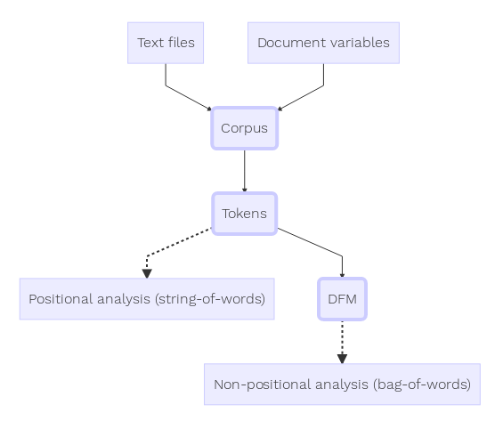

O primeiro deles, é o **Corpus**, que nada mais é do que uma coleção de documentos.

```r
corpus
```

```
Corpus consisting of 1,129 documents and 2 docvars.
```

Porém, lembre-se que estamos lidando tanto com discursos da Dilma quanto discursos do Temer, logo precisamos definir no nosso corpus qual discurso pertence a quem e em qual ano.

```r
quem_ano <- discursos %>% select(who, year)
docvars(corpus, c("who", "year")) <- quem_ano

summary(corpus)
```

Agora que temos um corpus, podemos transformá-los em **tokens**, que de forma bem rude, são as palavras de cada documento. Vamos também aproveitar para fazer algumas limpezas no nosso corpus, que seriam a remoção da pontuação e dos números.

```r
token <- tokens(corpus,
       include_docvars = T,
       remove_numbers = T,
       remove_punct = T)

head(token, n = 2)
```

No caso das Stopwords está definição pode nos ajudar:

> Stop words (ou palavras de parada – tradução livre) são palavras que podem ser consideradas irrelevantes para o conjunto de resultados a ser exibido em uma busca realizada em uma search engine. Exemplos: as, e, os, de, para, com, sem, foi.

Vamos finalmente transformar nossos tokens em DFM (Document Feature Matrix), também chamado de DTM (Document-Term Matrix). o DFM é uma matriz em que as linhas são os documentos, que no nosso caso são os discursos, e as colunas são os termos (palavras), o valor contido dentro das células indicam o quão frequente os termos são nos documentos.

A tabela abaixo é um exemplo de um DFM:

| … | casa | janela | porta |
| --- | --- | --- | --- |
| Doc1 | 2 | 5 | 0 |
| Doc2 | 4 | 0 | 0 |
| Doc3 | 0 | 0 | 1 |

Dizemos que a matriz é esparsa quando ela possui uma grande quantidade de zeros e em algumas análises isso pode ser um problema!

```r
sparsity(dfm_discursos) # % da matriz esparsa (% de zeros)
```

```
[1] 0.9776184
```

Vamos finalmente para as análises

- Frequência das palavras

|  | feature | frequency | rank | docfreq | group |
| --- | --- | --- | --- | --- | --- |
| 1 | quer | 11546 | 1 | 879 | Dilma |
| 2 | tod | 11141 | 2 | 901 | Dilma |
| 3 | aqu | 10409 | 3 | 828 | Dilma |
| 4 | país | 9731 | 4 | 890 | Dilma |
| 5 | brasil | 9689 | 5 | 888 | Dilma |
| 6 | porqu | 7941 | 6 | 775 | Dilma |
| 7 | govern | 7596 | 7 | 852 | Dilma |
| 8 | cumpriment | 7535 | 8 | 738 | Dilma |
| 9 | senhor | 6494 | 9 | 802 | Dilma |
| 10 | brasileir | 5702 | 10 | 851 | Dilma |

[output cut: 990 more lines]

[figure not shown]

```r
# Grafico do Temer
freq %>%
  filter(group == "Temer") %>%
  arrange(desc(frequency)) %>%
  slice(1:20) %>%
ggplot(aes(x = reorder(feature, frequency), y = frequency)) +
    geom_point() +
    coord_flip() +
    labs(x = NULL, y = "Frequency")
```

- Nuvem de palavras

[interactive chart not shown]

Observe os parâmetros da função wordcloud2, podemos mudar uma infinidade de coisas como por exemplo a cor de fundo e o tamanho da fonte

[interactive chart not shown]